# Stats 20, 21F – Homework 7

TAKAO OBA – 205615894

12/04/21

## Question 1

### (a)

```r
births <- read.csv("births.csv")
head(births)
```

```
##   Gender Premie weight Apgar1 Fage Mage Feduc Meduc TotPreg Visits   Marital
## 1   Male     No    124      8   31   25    13    14       1     13   Married
## 2 Female     No    177      8   36   26     9    12       2     11 Unmarried
## 3   Male     No    107      3   30   16    12     8       2     10 Unmarried
## 4 Female     No    144      6   33   37    12    14       2     12 Unmarried
## 5   Male     No    117      9   36   33    10    16       2     19   Married
## 6 Female     No     98      4   31   29    14    16       3     20   Married
##   Racemom Racedad Hispmom Hispdad Gained     Habit MomPriorCond BirthDef
## 1   White   White NotHisp NotHisp     40 NonSmoker         None     None
## 2   White   White Mexican Mexican     20 NonSmoker         None     None
## 3   White Unknown Mexican Unknown     70 NonSmoker At Least One     None
## 4   White   White NotHisp NotHisp     50 NonSmoker         None     None
## 5   White   Black NotHisp NotHisp     40 NonSmoker At Least One     None
## 6   White   White NotHisp NotHisp     21 NonSmoker         None     None
##      DelivComp BirthComp
## 1 At Least One      None
## 2 At Least One      None
## 3 At Least One      None
## 4 At Least One      None
## 5         None      None
## 6         None      None
```

```r
class(births)
```

```
## [1] "data.frame"
```

### (b)

```r
which(!((births$Habit == "NonSmoker") | (births$Habit == "Smoker")))
```

```
## [1]   41  577  684  984 1292 1501
```

```r
length(which(!((births$Habit == "NonSmoker") | (births$Habit == "Smoker"))))
```

```
## [1] 6
```

```r
births$Habit[41]
```

```
## [1] ""
```

```r
births$Habit[577]
```

```
## [1] ""
```

```r
births$Habit[684]
```

```
## [1] ""
```

```r
births$Habit[984]
```

```
## [1] ""
```

```r
births$Habit[1292]
```

```
## [1] ""
```

```r
births$Habit[1501]
```

```
## [1] ""
```

### (c)

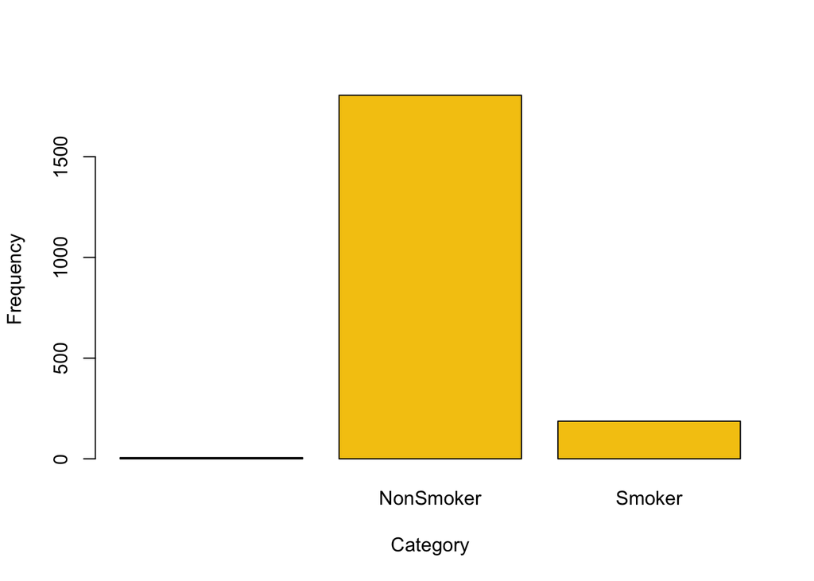

```r
habittable <- table(births$Habit)
barplot(habittable, xlab = "Category", ylab = "Frequency", col = 999)
```

### (d)

```r
# newbirths <- droplevels(births$Habit)
# levels(births$Habit)
```

### (e)

```r
#boxplot(births$Weight)
```

## Question 2

```r
with(births, hist(weight[Habit == "Smoker"], prob = TRUE, density = 50, col = "green", xlab = "Weight (in ounces)", main = "Histogram of Weight by\ntheir Mother's Smoking Habit", xlim = range(weight)))

with(births, hist(weight[Habit == "NonSmoker"], prob = TRUE, density = 40, col = "red", add = TRUE))
head(births)
```

```
##   Gender Premie weight Apgar1 Fage Mage Feduc Meduc TotPreg Visits   Marital
## 1   Male     No    124      8   31   25    13    14       1     13   Married
## 2 Female     No    177      8   36   26     9    12       2     11 Unmarried
## 3   Male     No    107      3   30   16    12     8       2     10 Unmarried
## 4 Female     No    144      6   33   37    12    14       2     12 Unmarried
## 5   Male     No    117      9   36   33    10    16       2     19   Married
## 6 Female     No     98      4   31   29    14    16       3     20   Married
##   Racemom Racedad Hispmom Hispdad Gained     Habit MomPriorCond BirthDef
## 1   White   White NotHisp NotHisp     40 NonSmoker         None     None
## 2   White   White Mexican Mexican     20 NonSmoker         None     None
## 3   White Unknown Mexican Unknown     70 NonSmoker At Least One     None
## 4   White   White NotHisp NotHisp     50 NonSmoker         None     None
## 5   White   Black NotHisp NotHisp     40 NonSmoker At Least One     None
## 6   White   White NotHisp NotHisp     21 NonSmoker         None     None
##      DelivComp BirthComp
## 1 At Least One      None
## 2 At Least One      None
## 3 At Least One      None
## 4 At Least One      None
## 5         None      None
## 6         None      None
```

[figure not shown]

```r
with(births, lines(density(weight[Habit == "Smoker"]), lwd = 3, col = "green"))

with(births, lines(density(weight[Habit == "NonSmoker"]), lwd = 3, col = "red"))

with(births, abline(v = summary(weight[Habit == "Smoker"])[3], lty = 2, lwd = 3, col = "green"))

with(births, abline(v = summary(weight[Habit == "NonSmoker"])[3], lty = 2, lwd = 3, col = "red"))

legend("topleft", c("Smoker", "Nonsmoker", "Density Estimate of Smoker", "Density Estimate of Nonsmoker", "Median of Smoker", "Median of Nonsmoker"), density = c(50, 40, NA, NA, NA, NA), fill = c("green", "red", 0, 0, 0, 0), border = c(1, 1, NA, NA, NA, NA), lty = c(NA, NA, 1, 1, 2, 2), lwd = c(NA, NA, 3, 3, 2, 2), col = c(NA, NA, "red", "green", "red", "green"), inset = 0.01)
```

## Question 3

### (a)

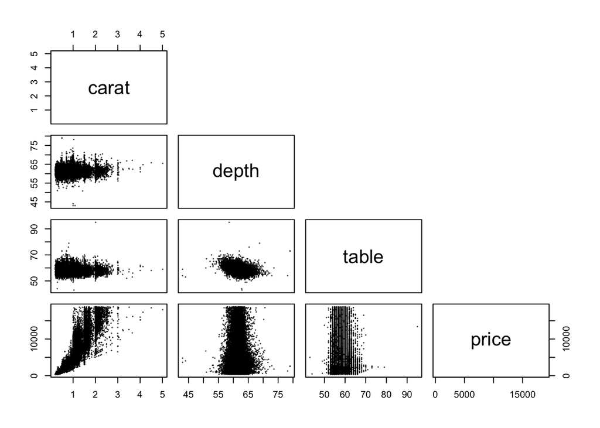

```r
library(ggplot2)

pairs(diamonds[-c(2, 3, 4, 8, 9, 10)], upper.panel = NULL, cex = 0.1)
```

The variables carat and price seem to have the strongest relationship. The relationship appears to be nonlinear.

### (b)

```r
sd(diamonds$carat)
```

```
## [1] 0.4740112
```

```r
sd(diamonds$price)
```

```
## [1] 3989.44
```

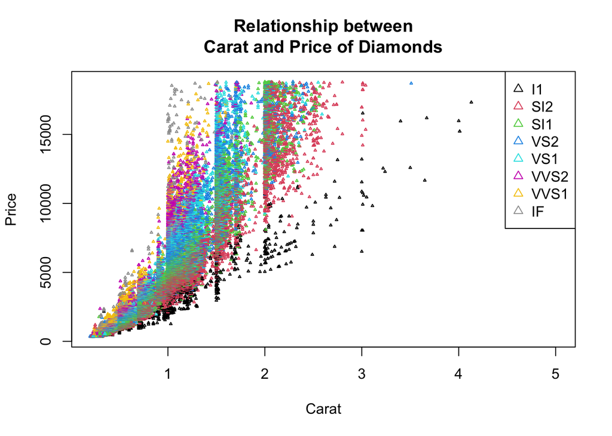

```r
plot(diamonds$price ~ diamonds$carat, pch = 2, cex = 0.3, col = diamonds$clarity, xlab = "Carat", ylab = "Price", main = "Relationship between\nCarat and Price of Diamonds")
legend("topright", c("I1", "SI2", "SI1", "VS2", "VS1", "VVS2", "VVS1", "IF"), pch = 2, cex = 1, col = c(1, 2, 3, 4, 5, 6, 7, 8))
```

```r
head(diamonds)
```

```
## # A tibble: 6 × 10
##   carat cut       color clarity depth table price     x     y     z
##   <dbl> <ord>     <ord> <ord>   <dbl> <dbl> <int> <dbl> <dbl> <dbl>
## 1  0.23 Ideal     E     SI2      61.5    55   326  3.95  3.98  2.43
## 2  0.21 Premium   E     SI1      59.8    61   326  3.89  3.84  2.31
## 3  0.23 Good      E     VS1      56.9    65   327  4.05  4.07  2.31
## 4  0.29 Premium   I     VS2      62.4    58   334  4.2   4.23  2.63
## 5  0.31 Good      J     SI2      63.3    58   335  4.34  4.35  2.75
## 6  0.24 Very Good J     VVS2     62.8    57   336  3.94  3.96  2.48
```

```r
class(diamonds$clarity)
```

```
## [1] "ordered" "factor"
```

```r
levels(diamonds$clarity)
```

```
## [1] "I1"   "SI2"  "SI1"  "VS2"  "VS1"  "VVS2" "VVS1" "IF"
```

```r
head(diamonds$clarity)
```

```
## [1] SI2  SI1  VS1  VS2  SI2  VVS2
## Levels: I1 < SI2 < SI1 < VS2 < VS1 < VVS2 < VVS1 < IF
```

The class of the clarity column is “ordered” “factors” and thus the default colors of 1 to 8 were chosen because these are the numbers that are generated when the factors are coerced into numeric values using the as.numeric function.

### (c)

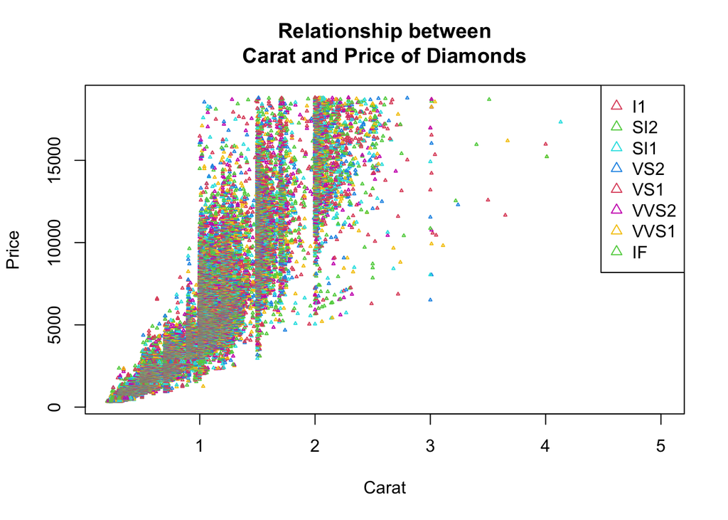

```r
plot(diamonds$price ~ diamonds$carat, pch = 2, cex = 0.3, col = as.integer(diamonds$clarity)[c(1, 2, 3, 4, 5, 6, 7, 8)], xlab = "Carat", ylab = "Price", main = "Relationship between\nCarat and Price of Diamonds")
legend("topright", c("I1", "SI2", "SI1", "VS2", "VS1", "VVS2", "VVS1", "IF"), pch = 2, cex = 1, col = as.integer(diamonds$clarity)[c(1, 2, 3, 4, 5, 6, 7, 8)])
```

### (d)

From the scatter plot, we can see how there is clearly a relationship between the clarity, carat, and the price of the diamond. Typically, as the carat is greater, the price is higher for the diamond, and certain clarities of the diamond generally has a higher price compared to other clarities. Additionally, certain clarities are only seen in the lower carats, which indicates that these rare clarities are extremely hard to find in higher carats or bigger diamonds.

## Question 4

### (a)

```r
mean_color_cut <- tapply(diamonds$price, list(diamonds$color, diamonds$cut), mean)
mean_color_cut
```

```
##       Fair     Good Very Good  Premium    Ideal
## D 4291.061 3405.382  3470.467 3631.293 2629.095
## E 3682.312 3423.644  3214.652 3538.914 2597.550
## F 3827.003 3495.750  3778.820 4324.890 3374.939
## G 4239.255 4123.482  3872.754 4500.742 3720.706
## H 5135.683 4276.255  4535.390 5216.707 3889.335
## I 4685.446 5078.533  5255.880 5946.181 4451.970
## J 4975.655 4574.173  5103.513 6294.592 4918.186
```

### (b)

```r
matplot(mean_color_cut, xaxt = "n", ylab = "Mean Price", lty = 1, lwd = 2, pch = 1)

levels(diamonds$cut)
```

```
## [1] "Fair"      "Good"      "Very Good" "Premium"   "Ideal"
```

```r
levels(diamonds$color)
```

```
## [1] "D" "E" "F" "G" "H" "I" "J"
```

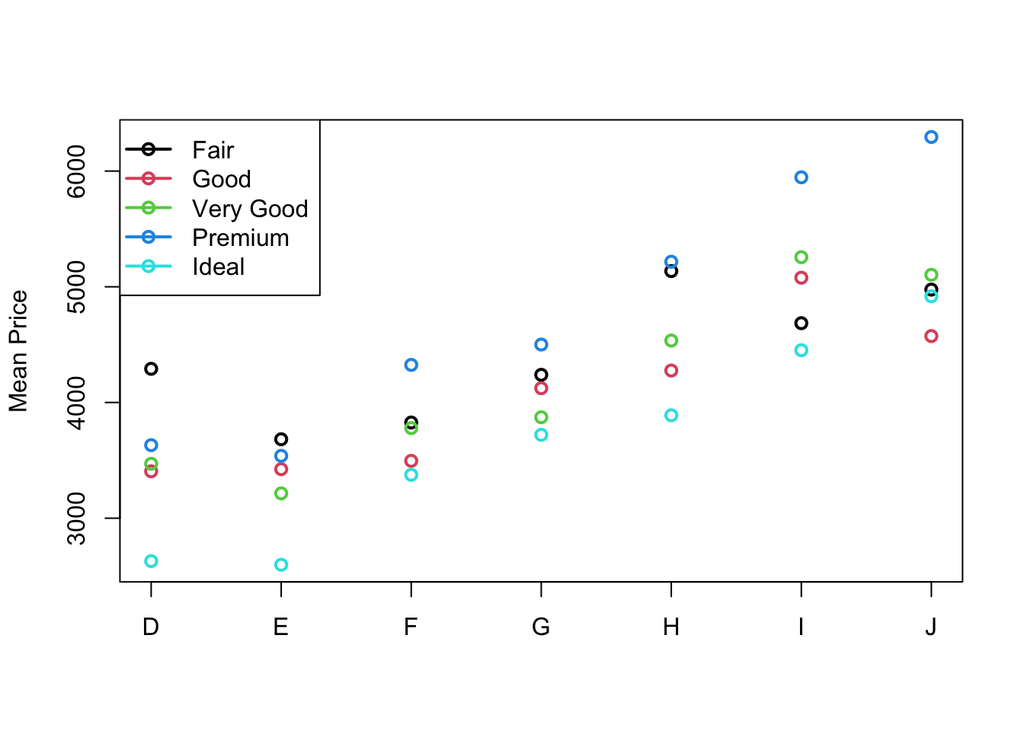

```r
axis(1, at = 1:7, labels = levels(diamonds$color))
legend("topleft", c("Fair", "Good", "Very Good", "Premium", "Ideal"), col = c(1, 2, 3, 4, 5), pch = 1, lwd = 2)
```

```r
?matplot
```